# A Crash Introduction to Regression

- Adapts Chapter 6 of *Introductory Statistics With R* by Peter Dalgaard, 2nd edition, Springer, 2008.
- The logistic regression example is from: http://statsmodels.sourceforge.net/stable/examples/notebooks/generated/discrete_choice_example.html?highlight=logistic

> Panos Louridas, Associate Professor  
> Department of Management Science and Technology  
> Athens University of Economics and Business  
> louridas@aueb.gr

# Regression

- We use regression when we want to examine the relationship between one variable (the dependent variable) and one or more other variables (the independent variables).
- In particular we want to find out whether the dependent variable really depends on the independent variables.
- In the simplest case, we have just two variables (the dependent and one independent), which we handle with simple linear regression analysis.
- Linear regression assumes that the relationship between the dependent variable $y$ and the independent variable $x$ is of the form:

$$y = \alpha + \beta x + \epsilon$$

- We have a set of $y_i$ and $x_i$ from our observations, we want to estimate $\alpha$ and $\beta$.

```python
import pandas as pd
import statsmodels.api as sm
import statsmodels.formula.api as smf
import statsmodels.graphics as sgr
import matplotlib.pyplot as plt
import numpy as np
from matplotlib.collections import LineCollection
from statsmodels.stats.outliers_influence import summary_table

%matplotlib inline

blood_df = pd.read_csv("thuesen.csv")
blood_df = blood_df.rename(columns={"blood.glucose": "blood_glucose",
                                    "short.velocity": "short_velocity"}) # make name pythonic
blood_df
```

|  | blood_glucose | short_velocity |
| --- | --- | --- |
| 0 | 15.3 | 1.76 |
| 1 | 10.8 | 1.34 |
| 2 | 8.1 | 1.27 |
| 3 | 19.5 | 1.47 |
| 4 | 7.2 | 1.27 |
| 5 | 5.3 | 1.49 |
| 6 | 9.3 | 1.31 |
| 7 | 11.1 | 1.09 |
| 8 | 7.5 | 1.18 |
| 9 | 12.2 | 1.22 |
| 10 | 6.7 | 1.25 |
| 11 | 5.2 | 1.19 |
| 12 | 19.0 | 1.95 |
| 13 | 15.1 | 1.28 |
| 14 | 6.7 | 1.52 |
| 15 | 8.6 | NaN |
| 16 | 4.2 | 1.12 |
| 17 | 10.3 | 1.37 |
| 18 | 12.5 | 1.19 |
| 19 | 16.1 | 1.05 |
| 20 | 13.3 | 1.32 |
| 21 | 4.9 | 1.03 |
| 22 | 8.8 | 1.12 |
| 23 | 9.5 | 1.70 |

- A straightforward way to do regression analysis with StatsModels is by using R-style formulas.
- We create a model and then fit it.
- The `params` attribute gives us the intercept and the slope of the regression line.

```python
mod = smf.ols("short_velocity ~ blood_glucose", data=blood_df)
blood_res = mod.fit()
blood_res.params
```

```
Intercept        1.097815
blood_glucose    0.021963
dtype: float64
```

- If we want a summary of all regression results and parametres, we call the `summary` method on the results.

```python
blood_res.summary()
```

OLS Regression Results

| Dep. Variable: | short_velocity | R-squared: | 0.174 |
| --- | --- | --- | --- |
| Model: | OLS | Adj. R-squared: | 0.134 |
| Method: | Least Squares | F-statistic: | 4.414 |
| Date: | Thu, 10 Nov 2016 | Prob (F-statistic): | 0.0479 |
| Time: | 17:24:56 | Log-Likelihood: | 3.5836 |
| No. Observations: | 23 | AIC: | -3.167 |
| Df Residuals: | 21 | BIC: | -0.8962 |
| Df Model: | 1 |  |  |
| Covariance Type: | nonrobust |  |  |

|  | coef | std err | t | P>\|t\| | [95.0% Conf. Int.] |
| --- | --- | --- | --- | --- | --- |
| Intercept | 1.0978 | 0.117 | 9.345 | 0.000 | 0.853 1.342 |
| blood_glucose | 0.0220 | 0.010 | 2.101 | 0.048 | 0.000 0.044 |

| Omnibus: | 1.717 | Durbin-Watson: | 1.802 |
| --- | --- | --- | --- |
| Prob(Omnibus): | 0.424 | Jarque-Bera (JB): | 1.270 |
| Skew: | 0.562 | Prob(JB): | 0.530 |
| Kurtosis: | 2.756 | Cond. No. | 29.4 |

- To see what regression tells us, it is useful to draw a diagram.
- The diagram will contain the observations and the regression line that we found.

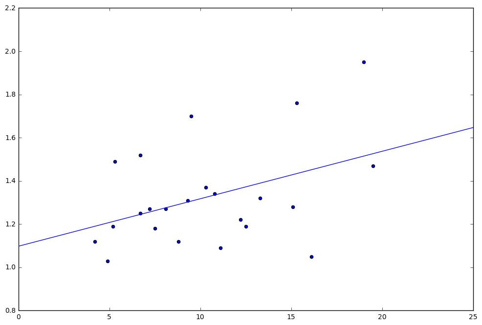

```python
fig = plt.figure(figsize=(12,8))
ax = fig.add_subplot(111)

blood_glucose = blood_df.blood_glucose.values
short_velocity = blood_df.short_velocity.values
ax.scatter(blood_glucose, short_velocity)
fig = sgr.regressionplots.abline_plot(model_results=blood_res, ax=ax)
```

- It is also useful to plot the observed data along with the *fitted* data, that is, the data on the regression line that correspond to the $x$ values.

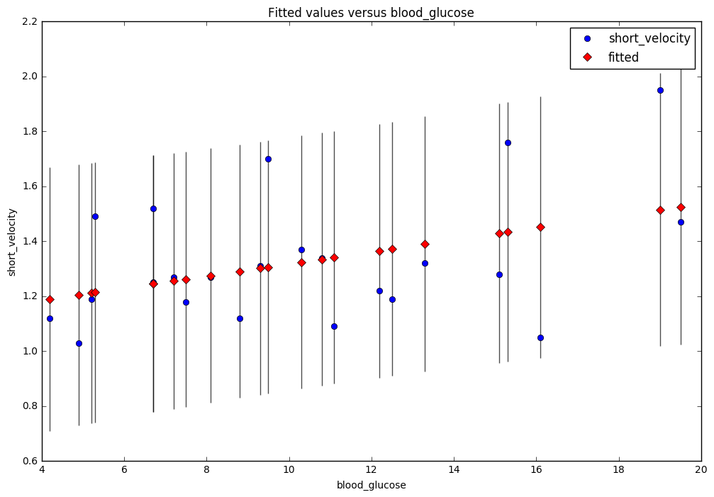

```python
fig = plt.figure(figsize=(12,8))
ax = fig.add_subplot(111)
fig = sgr.regressionplots.plot_fit(blood_res, 1, ax=ax)
```

- The vertical lines are pointwise prediction intervals.
- The prediction intervals show the range that will include with 95% probability the $y$ value for a given $x$ value.
- It is also useful to plot the *regression confidence interval*. This is the 95% confidence interval for the *regression line*.
- It is different from the *prediction confidence interval*, which is the 95% confidence interval for our predictions.
- We can see them both on one figure.
- To create the figure we have to do some work.
- First, we have to make sure that the data do not contain NaNs and are sorted on the $x$ axis.
- Then, we must extract the regression confidence intervals and the prediction confidence intervals from a data structure returned by the `summary_table` function.
- In particular, the regression confidence intervals are columns 4, 5 and the prediction confidence intervals are columns 6, 7 of the second return value of the `summary_table` function.
- Admittedly, this is ugly; but it does gives us some extra info on what regression really does.

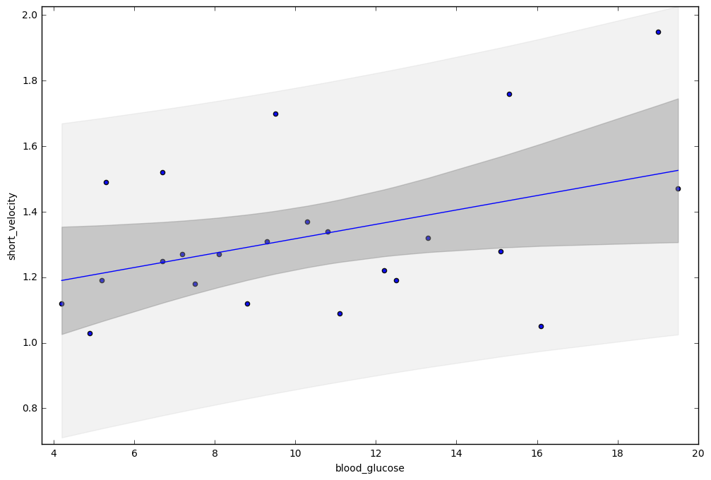

```python
blood_df = blood_df.dropna()
blood_df = blood_df.sort_values(by='blood_glucose')
mod = smf.ols("short_velocity ~ blood_glucose", data=blood_df)
blood_res = mod.fit()

blood_glucose = blood_df.blood_glucose.values
short_velocity = blood_df.short_velocity.values
fitted = blood_res.fittedvalues.values

fig = plt.figure(figsize=(12,8))
ax = fig.add_subplot(111)
ax.set_xlim(np.amin(blood_glucose) - 0.5, np.amax(blood_glucose)  + 0.5)
ax.set_ylim(np.amin(fitted) - 0.5, np.amax(fitted) + 0.5)
ax.scatter(blood_glucose, short_velocity)
ax.plot(blood_glucose, blood_res.fittedvalues, 'b-')

st, data, ss2 = summary_table(blood_res, alpha=0.05)

predict_ci_l, predict_ci_u = data[:,6:8].T
ax.fill_between(blood_glucose, predict_ci_l, predict_ci_u, color='#888888', alpha=0.1)

mean_ci_l, mean_ci_u = data[:,4:6].T
ax.fill_between(blood_glucose, mean_ci_l, mean_ci_u, color='#888888', alpha=0.4)
ax.set_xlabel('blood_glucose')
ax.set_ylabel('short_velocity')
```

# $R^2$

- What is $R^2$?
- If $R^2 = 1$ then the all the $y_i$ fall into the regression line; the line fits the data perfectly.
- If $R^2 = 0$ then the regression line does not fit the data at all.
- Let's see an example.
- We will create an artificial data set, where the values of $y$ are derived from $x$ with some noise added to them.
- The noise will be larger towards the two ends of the interval of $x$ values, smaller around the middle of the $x$ interval.

```python
x = np.arange(1, 101)
y = (x - 50)*5 * np.random.randint(0, 100, size=100)
x = sm.add_constant(x)
```

```python
x[:5]
```

```
array([[ 1.,  1.],
       [ 1.,  2.],
       [ 1.,  3.],
       [ 1.,  4.],
       [ 1.,  5.]])
```

```python
y[:5]
```

```
array([-21315, -21120, -12455, -15180, -21600])
```

```python
mod = sm.OLS(y, x)
res = mod.fit()
res.summary()
```

OLS Regression Results

| Dep. Variable: | y | R-squared: | 0.823 |
| --- | --- | --- | --- |
| Model: | OLS | Adj. R-squared: | 0.822 |
| Method: | Least Squares | F-statistic: | 456.6 |
| Date: | Thu, 10 Nov 2016 | Prob (F-statistic): | 1.15e-38 |
| Time: | 17:24:57 | Log-Likelihood: | -968.36 |
| No. Observations: | 100 | AIC: | 1941. |
| Df Residuals: | 98 | BIC: | 1946. |
| Df Model: | 1 |  |  |
| Covariance Type: | nonrobust |  |  |

|  | coef | std err | t | P>\|t\| | [95.0% Conf. Int.] |
| --- | --- | --- | --- | --- | --- |
| const | -1.438e+04 | 790.630 | -18.186 | 0.000 | -1.59e+04 -1.28e+04 |
| x1 | 290.4562 | 13.592 | 21.369 | 0.000 | 263.483 317.430 |

| Omnibus: | 3.699 | Durbin-Watson: | 2.169 |
| --- | --- | --- | --- |
| Prob(Omnibus): | 0.157 | Jarque-Bera (JB): | 3.261 |
| Skew: | -0.274 | Prob(JB): | 0.196 |
| Kurtosis: | 3.694 | Cond. No. | 117. |

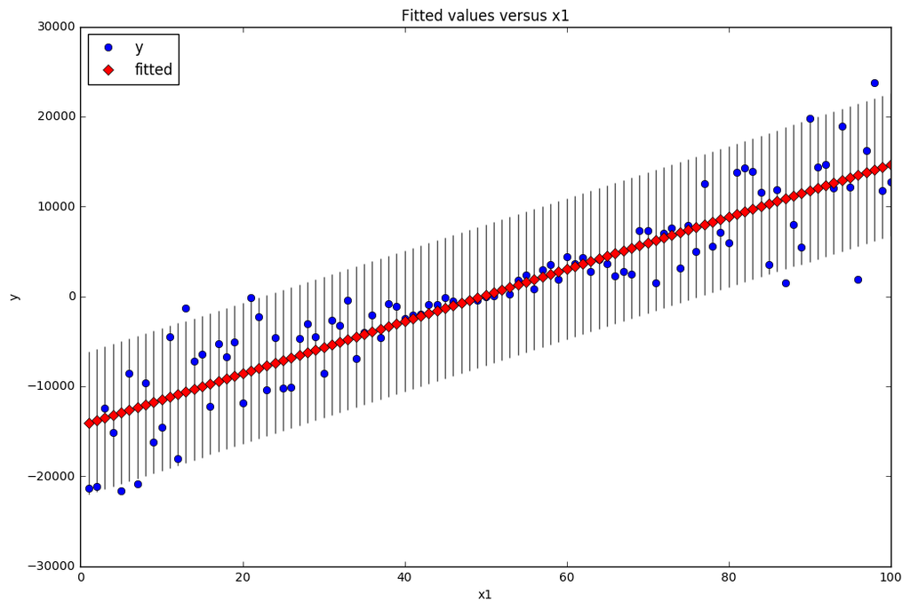

```python
fig = plt.figure(figsize=(12,8))
ax = fig.add_subplot(111)
fig = sgr.regressionplots.plot_fit(res, 1, ax = ax)
```

- We denote by $\bar{y}$ the mean of the observed data:

$$\bar{y}=\frac{1}{n}\sum_{i=1}^n y_i$$

- By $SS_\text{tot}$ the total sum of squares:

$$SS_\text{tot}=\sum_i (y_i-\bar{y})^2$$

- By $SS_\text{res}$ the residuals sum of squares:

$$ SS_\text{res}=\sum_i (y_i - f_i)^2 $$

- For example, if $R^2 = 0.49$, it means that our regression model explains 49% of the variability between the two variables. The other 51% remains unaccounted for.

# Residuals and Fitted Values

- Apart from the overall summary, we can extract other useful information.
- This includes residuals and fitted values.
- To extract the fitted values:

```python
blood_res.fittedvalues
```

```
16    1.190057
21    1.205431
11    1.212020
5     1.214216
14    1.244964
10    1.244964
4     1.255945
8     1.262534
2     1.275711
22    1.291085
6     1.302066
23    1.306459
17    1.324029
1     1.335010
7     1.341599
9     1.365758
18    1.372346
20    1.389916
13    1.429449
0     1.433841
19    1.451411
12    1.515103
3     1.526084
dtype: float64
```

- To extract the residuals:

```python
blood_res.resid
```

```
16   -0.070057
21   -0.175431
11   -0.022020
5     0.275784
14    0.275036
10    0.005036
4     0.014055
8    -0.082534
2    -0.005711
22   -0.171085
6     0.007934
23    0.393541
17    0.045971
1     0.004990
7    -0.251599
9    -0.145758
18   -0.182346
20   -0.069916
13   -0.149449
0     0.326159
19   -0.401411
12    0.434897
3    -0.056084
dtype: float64
```

- What OLS really tries to do is to minimise the squares of the distances of the residuals from the regression line.

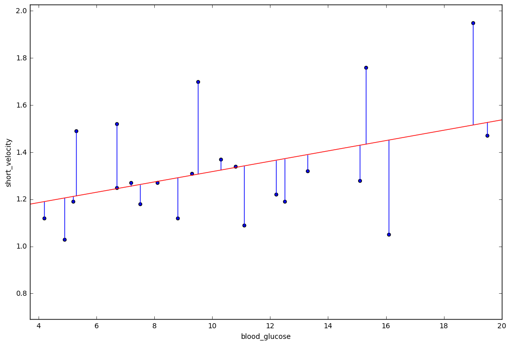

```python
fitted_coords = zip(blood_glucose, fitted)
data_coords = zip(blood_glucose, short_velocity)
segment_coords = list(zip(fitted_coords, data_coords))
line_segments = LineCollection(segment_coords,
                               colors=('blue'),
                               linewidths=(1),
                               linestyles='solid')

fig = plt.figure(figsize=(12,8))
ax = fig.add_subplot(111)
ax.set_xlim(np.amin(blood_glucose) - 0.5, np.amax(blood_glucose)  + 0.5)
ax.set_ylim(np.amin(fitted) - 0.5, np.amax(fitted) + 0.5)
ax.add_collection(line_segments)

ax.scatter(blood_glucose, short_velocity)
fig = sgr.regressionplots.abline_plot(model_results=blood_res, ax=ax, color='r')
ax.set_xlabel('blood_glucose')
ax.set_ylabel('short_velocity')
```

- The residuals should not show a pattern when plot against the fitted values.

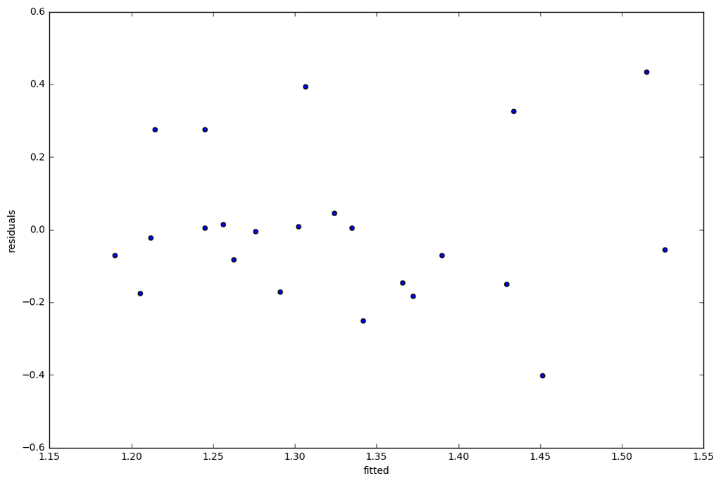

```python
fig = plt.figure(figsize=(12,8))
ax = fig.add_subplot(111)
ax.scatter(fitted, blood_res.resid)
ax.set_xlabel('fitted')
ax.set_ylabel('residuals')
```

- In OLS, we expect residuals to follow, roughly, the normal distribution with a mean of 0 and some constant variance.
- To get an indication of whether residuals come from a normal distribution, we can check for a straight line on a Q-Q plot.

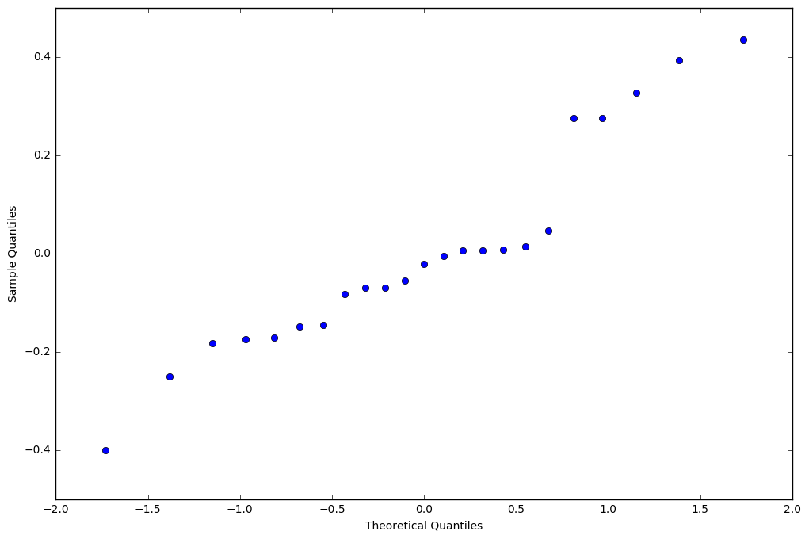

```python
fig = plt.figure(figsize=(12,8))
ax = fig.add_subplot(111)
fig = sm.qqplot(blood_res.resid, ax=ax)
```

# Logistic Regression

- When the response variable is binary, we cannot use ordinary regression.
- That is because ordinary regression assumes that the response is a continuous variable.
- We can use instead *logistic regression*.
- In logistic regression we want to model the conditional probability $P(Y = 1 | X = x)$.
- A convenient transformation is the *logit* or *logistic* transformation:

$$ log\frac{p}{1 - p} $$

- That means that the logistic regression model is:

$$ log\frac{p}{1 - p} = \beta_0 + \beta_1 x$$

- And we have, solving for $p(x)$:

$$ p(x) = \frac {1}{1+e^{-(\beta_0 + \beta_1 x)}} $$

- We can see that this function looks like an S.

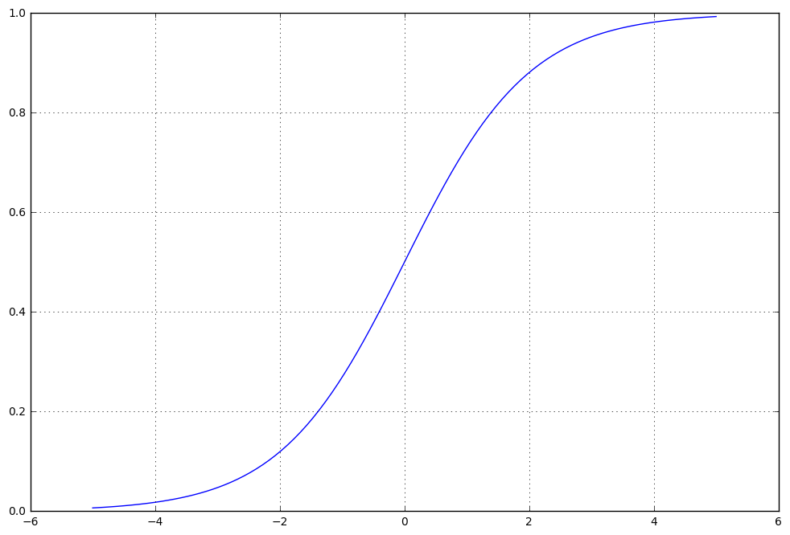

```python
fig = plt.figure(figsize=(12,8))
ax = fig.add_subplot(111)
x = np.linspace(-5, 5,100)
y = 1 / (1 + np.exp(-x))
ax.plot(x, y)
ax.grid(True)
```

- As an example, we'll use Fair's Affair data.
- That was a survey of women only was conducted in 1974 by Redbook asking about extramarital affairs.
- We'll import the `logit` formula function.

```python
from statsmodels.formula.api import logit
```

- This is the dataset source details:

```python
print(sm.datasets.fair.SOURCE)
```

```
Fair, Ray. 1978. "A Theory of Extramarital Affairs," `Journal of Political
    Economy`, February, 45-61.

The data is available at http://fairmodel.econ.yale.edu/rayfair/pdf/2011b.htm
```

- And here are the dataset description.

```python
print( sm.datasets.fair.NOTE)
```

```
::

    Number of observations: 6366
    Number of variables: 9
    Variable name definitions:

        rate_marriage   : How rate marriage, 1 = very poor, 2 = poor, 3 = fair,
                        4 = good, 5 = very good
        age             : Age
        yrs_married     : No. years married. Interval approximations. See
                        original paper for detailed explanation.
        children        : No. children
        religious       : How relgious, 1 = not, 2 = mildly, 3 = fairly,
                        4 = strongly
        educ            : Level of education, 9 = grade school, 12 = high
                        school, 14 = some college, 16 = college graduate,
                        17 = some graduate school, 20 = advanced degree
        occupation      : 1 = student, 2 = farming, agriculture; semi-skilled,
                        or unskilled worker; 3 = white-colloar; 4 = teacher
                        counselor social worker, nurse; artist, writers;
                        technician, skilled worker, 5 = managerial,
                        administrative, business, 6 = professional with
                        advanced degree
        occupation_husb : Husband's occupation. Same as occupation.
        affairs         : measure of time spent in extramarital affairs

    See the original paper for more details.
```

- We'll read the data and then add a binary variable that will indicate whether a responder had an extramarital affair or not.
- We'll create an `affair` column, which will be equal to 1.0 if there have been affairs or 0.0 otherwise.

```python
dta = sm.datasets.fair.load_pandas().data

dta['affair'] = (dta['affairs'] > 0).astype(float)

dta.head(10)
```

|  | rate_marriage | age | yrs_married | children | religious | educ | occupation | occupation_husb | affairs | affair |
| --- | --- | --- | --- | --- | --- | --- | --- | --- | --- | --- |
| 0 | 3.0 | 32.0 | 9.0 | 3.0 | 3.0 | 17.0 | 2.0 | 5.0 | 0.111111 | 1.0 |
| 1 | 3.0 | 27.0 | 13.0 | 3.0 | 1.0 | 14.0 | 3.0 | 4.0 | 3.230769 | 1.0 |
| 2 | 4.0 | 22.0 | 2.5 | 0.0 | 1.0 | 16.0 | 3.0 | 5.0 | 1.400000 | 1.0 |
| 3 | 4.0 | 37.0 | 16.5 | 4.0 | 3.0 | 16.0 | 5.0 | 5.0 | 0.727273 | 1.0 |
| 4 | 5.0 | 27.0 | 9.0 | 1.0 | 1.0 | 14.0 | 3.0 | 4.0 | 4.666666 | 1.0 |
| 5 | 4.0 | 27.0 | 9.0 | 0.0 | 2.0 | 14.0 | 3.0 | 4.0 | 4.666666 | 1.0 |
| 6 | 5.0 | 37.0 | 23.0 | 5.5 | 2.0 | 12.0 | 5.0 | 4.0 | 0.852174 | 1.0 |
| 7 | 5.0 | 37.0 | 23.0 | 5.5 | 2.0 | 12.0 | 2.0 | 3.0 | 1.826086 | 1.0 |
| 8 | 3.0 | 22.0 | 2.5 | 0.0 | 2.0 | 12.0 | 3.0 | 3.0 | 4.799999 | 1.0 |
| 9 | 3.0 | 27.0 | 6.0 | 0.0 | 1.0 | 16.0 | 3.0 | 5.0 | 1.333333 | 1.0 |

- Now we can run logistic regression on the data.
- The dependent variable will be the `affair` column we've just created.

```python
affair_mod = logit("affair ~ occupation + educ + occupation_husb"
                   " + rate_marriage + age + yrs_married + children"
                   " + religious", dta).fit()

affair_mod.summary()
```

```
Optimization terminated successfully.
         Current function value: 0.545314
         Iterations 6
```

Logit Regression Results

| Dep. Variable: | affair | No. Observations: | 6366 |
| --- | --- | --- | --- |
| Model: | Logit | Df Residuals: | 6357 |
| Method: | MLE | Df Model: | 8 |
| Date: | Thu, 10 Nov 2016 | Pseudo R-squ.: | 0.1327 |
| Time: | 17:25:00 | Log-Likelihood: | -3471.5 |
| converged: | True | LL-Null: | -4002.5 |
|  |  | LLR p-value: | 5.807e-224 |

|  | coef | std err | z | P>\|z\| | [95.0% Conf. Int.] |
| --- | --- | --- | --- | --- | --- |
| Intercept | 3.7257 | 0.299 | 12.470 | 0.000 | 3.140 4.311 |
| occupation | 0.1602 | 0.034 | 4.717 | 0.000 | 0.094 0.227 |
| educ | -0.0392 | 0.015 | -2.533 | 0.011 | -0.070 -0.009 |
| occupation_husb | 0.0124 | 0.023 | 0.541 | 0.589 | -0.033 0.057 |
| rate_marriage | -0.7161 | 0.031 | -22.784 | 0.000 | -0.778 -0.655 |
| age | -0.0605 | 0.010 | -5.885 | 0.000 | -0.081 -0.040 |
| yrs_married | 0.1100 | 0.011 | 10.054 | 0.000 | 0.089 0.131 |
| children | -0.0042 | 0.032 | -0.134 | 0.893 | -0.066 0.058 |
| religious | -0.3752 | 0.035 | -10.792 | 0.000 | -0.443 -0.307 |